# Lab 11

Author

Olivia Kelly

```r
library(tidyverse)
```

### Examples

```r
species <- tibble(id = c(1, 2, 3),
              name = c("Species1", "Species2", "Species3"))

abundance <- tibble(id = c(2, 3, 4),
              abundance = c(85, 90, 95))
```

```r
left_join(species, abundance, by = "id")
```

```
# A tibble: 3 × 3
     id name     abundance
  <dbl> <chr>        <dbl>
1     1 Species1        NA
2     2 Species2        85
3     3 Species3        90
```

```r
inner_join(species, abundance, by = "id")
```

```
# A tibble: 2 × 3
     id name     abundance
  <dbl> <chr>        <dbl>
1     2 Species2        85
2     3 Species3        90
```

```r
full_join(species, abundance, by = "id")
```

```
# A tibble: 4 × 3
     id name     abundance
  <dbl> <chr>        <dbl>
1     1 Species1        NA
2     2 Species2        85
3     3 Species3        90
4     4 <NA>            95
```

```r
library(nycflights13)
```

```r
airlines
```

```
# A tibble: 16 × 2
   carrier name
   <chr>   <chr>
 1 9E      Endeavor Air Inc.
 2 AA      American Airlines Inc.
 3 AS      Alaska Airlines Inc.
 4 B6      JetBlue Airways
 5 DL      Delta Air Lines Inc.
 6 EV      ExpressJet Airlines Inc.
 7 F9      Frontier Airlines Inc.
 8 FL      AirTran Airways Corporation
 9 HA      Hawaiian Airlines Inc.
10 MQ      Envoy Air
11 OO      SkyWest Airlines Inc.
12 UA      United Air Lines Inc.
13 US      US Airways Inc.
14 VX      Virgin America
15 WN      Southwest Airlines Co.
16 YV      Mesa Airlines Inc.
```

```
#> # A tibble: 16 × 2
#>   carrier name
#>   <chr>   <chr>
#> 1 9E      Endeavor Air Inc.
#> 2 AA      American Airlines Inc.
#> 3 AS      Alaska Airlines Inc.
#> 4 B6      JetBlue Airways
#> 5 DL      Delta Air Lines Inc.
#> 6 EV      ExpressJet Airlines Inc.
#> # ℹ 10 more rows
```

```r
airports
```

```
# A tibble: 1,458 × 8
   faa   name                             lat    lon   alt    tz dst   tzone
   <chr> <chr>                          <dbl>  <dbl> <dbl> <dbl> <chr> <chr>
 1 04G   Lansdowne Airport               41.1  -80.6  1044    -5 A     America/…
 2 06A   Moton Field Municipal Airport   32.5  -85.7   264    -6 A     America/…
 3 06C   Schaumburg Regional             42.0  -88.1   801    -6 A     America/…
 4 06N   Randall Airport                 41.4  -74.4   523    -5 A     America/…
 5 09J   Jekyll Island Airport           31.1  -81.4    11    -5 A     America/…
 6 0A9   Elizabethton Municipal Airport  36.4  -82.2  1593    -5 A     America/…
 7 0G6   Williams County Airport         41.5  -84.5   730    -5 A     America/…
 8 0G7   Finger Lakes Regional Airport   42.9  -76.8   492    -5 A     America/…
 9 0P2   Shoestring Aviation Airfield    39.8  -76.6  1000    -5 U     America/…
10 0S9   Jefferson County Intl           48.1 -123.    108    -8 A     America/…
# ℹ 1,448 more rows
```

```
#> # A tibble: 1,458 × 8
#>   faa   name                            lat   lon   alt    tz dst
#>   <chr> <chr>                         <dbl> <dbl> <dbl> <dbl> <chr>
#> 1 04G   Lansdowne Airport              41.1 -80.6  1044    -5 A
#> 2 06A   Moton Field Municipal Airport  32.5 -85.7   264    -6 A
#> 3 06C   Schaumburg Regional            42.0 -88.1   801    -6 A
#> 4 06N   Randall Airport                41.4 -74.4   523    -5 A
#> 5 09J   Jekyll Island Airport          31.1 -81.4    11    -5 A
#> 6 0A9   Elizabethton Municipal Airpo…  36.4 -82.2  1593    -5 A
#> # ℹ 1,452 more rows
#> # ℹ 1 more variable: tzone <chr>
```

```r
planes
```

```
# A tibble: 3,322 × 9
   tailnum  year type              manufacturer model engines seats speed engine
   <chr>   <int> <chr>             <chr>        <chr>   <int> <int> <int> <chr>
 1 N10156   2004 Fixed wing multi… EMBRAER      EMB-…       2    55    NA Turbo…
 2 N102UW   1998 Fixed wing multi… AIRBUS INDU… A320…       2   182    NA Turbo…
 3 N103US   1999 Fixed wing multi… AIRBUS INDU… A320…       2   182    NA Turbo…
 4 N104UW   1999 Fixed wing multi… AIRBUS INDU… A320…       2   182    NA Turbo…
 5 N10575   2002 Fixed wing multi… EMBRAER      EMB-…       2    55    NA Turbo…
 6 N105UW   1999 Fixed wing multi… AIRBUS INDU… A320…       2   182    NA Turbo…
 7 N107US   1999 Fixed wing multi… AIRBUS INDU… A320…       2   182    NA Turbo…
 8 N108UW   1999 Fixed wing multi… AIRBUS INDU… A320…       2   182    NA Turbo…
 9 N109UW   1999 Fixed wing multi… AIRBUS INDU… A320…       2   182    NA Turbo…
10 N110UW   1999 Fixed wing multi… AIRBUS INDU… A320…       2   182    NA Turbo…
# ℹ 3,312 more rows
```

```
#> # A tibble: 3,322 × 9
#>   tailnum  year type              manufacturer    model     engines
#>   <chr>   <int> <chr>             <chr>           <chr>       <int>
#> 1 N10156   2004 Fixed wing multi… EMBRAER         EMB-145XR       2
#> 2 N102UW   1998 Fixed wing multi… AIRBUS INDUSTR… A320-214        2
#> 3 N103US   1999 Fixed wing multi… AIRBUS INDUSTR… A320-214        2
#> 4 N104UW   1999 Fixed wing multi… AIRBUS INDUSTR… A320-214        2
#> 5 N10575   2002 Fixed wing multi… EMBRAER         EMB-145LR       2
#> 6 N105UW   1999 Fixed wing multi… AIRBUS INDUSTR… A320-214        2
#> # ℹ 3,316 more rows
#> # ℹ 3 more variables: seats <int>, speed <int>, engine <chr>
```

```r
weather
```

```
# A tibble: 26,115 × 15
   origin  year month   day  hour  temp  dewp humid wind_dir wind_speed
   <chr>  <int> <int> <int> <int> <dbl> <dbl> <dbl>    <dbl>      <dbl>
 1 EWR     2013     1     1     1  39.0  26.1  59.4      270      10.4
 2 EWR     2013     1     1     2  39.0  27.0  61.6      250       8.06
 3 EWR     2013     1     1     3  39.0  28.0  64.4      240      11.5
 4 EWR     2013     1     1     4  39.9  28.0  62.2      250      12.7
 5 EWR     2013     1     1     5  39.0  28.0  64.4      260      12.7
 6 EWR     2013     1     1     6  37.9  28.0  67.2      240      11.5
 7 EWR     2013     1     1     7  39.0  28.0  64.4      240      15.0
 8 EWR     2013     1     1     8  39.9  28.0  62.2      250      10.4
 9 EWR     2013     1     1     9  39.9  28.0  62.2      260      15.0
10 EWR     2013     1     1    10  41    28.0  59.6      260      13.8
# ℹ 26,105 more rows
# ℹ 5 more variables: wind_gust <dbl>, precip <dbl>, pressure <dbl>,
#   visib <dbl>, time_hour <dttm>
```

```
#> # A tibble: 26,115 × 15
#>   origin  year month   day  hour  temp  dewp humid wind_dir
#>   <chr>  <int> <int> <int> <int> <dbl> <dbl> <dbl>    <dbl>
#> 1 EWR     2013     1     1     1  39.0  26.1  59.4      270
#> 2 EWR     2013     1     1     2  39.0  27.0  61.6      250
#> 3 EWR     2013     1     1     3  39.0  28.0  64.4      240
#> 4 EWR     2013     1     1     4  39.9  28.0  62.2      250
#> 5 EWR     2013     1     1     5  39.0  28.0  64.4      260
#> 6 EWR     2013     1     1     6  37.9  28.0  67.2      240
#> # ℹ 26,109 more rows
#> # ℹ 6 more variables: wind_speed <dbl>, wind_gust <dbl>, …
```

```r
planes |>
  count(tailnum) |>
  filter(n > 1)
```

```
# A tibble: 0 × 2
# ℹ 2 variables: tailnum <chr>, n <int>
```

```
#> # A tibble: 0 × 2
#> # ℹ 2 variables: tailnum <chr>, n <int>
```

```r
weather |>
  count(time_hour, origin) |>
  filter(n > 1)
```

```
# A tibble: 0 × 3
# ℹ 3 variables: time_hour <dttm>, origin <chr>, n <int>
```

```
#> # A tibble: 0 × 3
#> # ℹ 3 variables: time_hour <dttm>, origin <chr>, n <int>
```

```r
planes |>
  filter(is.na(tailnum))
```

```
# A tibble: 0 × 9
# ℹ 9 variables: tailnum <chr>, year <int>, type <chr>, manufacturer <chr>,
#   model <chr>, engines <int>, seats <int>, speed <int>, engine <chr>
```

```
#> # A tibble: 0 × 9
#> # ℹ 9 variables: tailnum <chr>, year <int>, type <chr>, manufacturer <chr>,
#> #   model <chr>, engines <int>, seats <int>, speed <int>, engine <chr>
```

```r
weather |>
  filter(is.na(time_hour) | is.na(origin))
```

```
# A tibble: 0 × 15
# ℹ 15 variables: origin <chr>, year <int>, month <int>, day <int>, hour <int>,
#   temp <dbl>, dewp <dbl>, humid <dbl>, wind_dir <dbl>, wind_speed <dbl>,
#   wind_gust <dbl>, precip <dbl>, pressure <dbl>, visib <dbl>,
#   time_hour <dttm>
```

```
#> # A tibble: 0 × 15
#> # ℹ 15 variables: origin <chr>, year <int>, month <int>, day <int>,
#> #   hour <int>, temp <dbl>, dewp <dbl>, humid <dbl>, wind_dir <dbl>, …
```

```r
flights |>
  count(time_hour, carrier, flight) |>
  filter(n > 1)
```

```
# A tibble: 0 × 4
# ℹ 4 variables: time_hour <dttm>, carrier <chr>, flight <int>, n <int>
```

```
#> # A tibble: 0 × 4
#> # ℹ 4 variables: time_hour <dttm>, carrier <chr>, flight <int>, n <int>
```

```r
airports |>
  count(alt, lat) |>
  filter(n > 1)
```

```
# A tibble: 1 × 3
    alt   lat     n
  <dbl> <dbl> <int>
1    13  40.6     2
```

```
#> # A tibble: 1 × 3
#>     alt   lat     n
#>   <dbl> <dbl> <int>
#> 1    13  40.6     2
```

```r
flights2 <- flights |>
  mutate(id = row_number(), .before = 1)
flights2
```

```
# A tibble: 336,776 × 20
      id  year month   day dep_time sched_dep_time dep_delay arr_time
   <int> <int> <int> <int>    <int>          <int>     <dbl>    <int>
 1     1  2013     1     1      517            515         2      830
 2     2  2013     1     1      533            529         4      850
 3     3  2013     1     1      542            540         2      923
 4     4  2013     1     1      544            545        -1     1004
 5     5  2013     1     1      554            600        -6      812
 6     6  2013     1     1      554            558        -4      740
 7     7  2013     1     1      555            600        -5      913
 8     8  2013     1     1      557            600        -3      709
 9     9  2013     1     1      557            600        -3      838
10    10  2013     1     1      558            600        -2      753
# ℹ 336,766 more rows
# ℹ 12 more variables: sched_arr_time <int>, arr_delay <dbl>, carrier <chr>,
#   flight <int>, tailnum <chr>, origin <chr>, dest <chr>, air_time <dbl>,
#   distance <dbl>, hour <dbl>, minute <dbl>, time_hour <dttm>
```

```
#> # A tibble: 336,776 × 20
#>      id  year month   day dep_time sched_dep_time dep_delay arr_time
#>   <int> <int> <int> <int>    <int>          <int>     <dbl>    <int>
#> 1     1  2013     1     1      517            515         2      830
#> 2     2  2013     1     1      533            529         4      850
#> 3     3  2013     1     1      542            540         2      923
#> 4     4  2013     1     1      544            545        -1     1004
#> 5     5  2013     1     1      554            600        -6      812
#> 6     6  2013     1     1      554            558        -4      740
#> # ℹ 336,770 more rows
#> # ℹ 12 more variables: sched_arr_time <int>, arr_delay <dbl>, …
```

```r
flights2 <- flights |>
  select(year, time_hour, origin, dest, tailnum, carrier)
flights2
```

```
# A tibble: 336,776 × 6
    year time_hour           origin dest  tailnum carrier
   <int> <dttm>              <chr>  <chr> <chr>   <chr>
 1  2013 2013-01-01 05:00:00 EWR    IAH   N14228  UA
 2  2013 2013-01-01 05:00:00 LGA    IAH   N24211  UA
 3  2013 2013-01-01 05:00:00 JFK    MIA   N619AA  AA
 4  2013 2013-01-01 05:00:00 JFK    BQN   N804JB  B6
 5  2013 2013-01-01 06:00:00 LGA    ATL   N668DN  DL
 6  2013 2013-01-01 05:00:00 EWR    ORD   N39463  UA
 7  2013 2013-01-01 06:00:00 EWR    FLL   N516JB  B6
 8  2013 2013-01-01 06:00:00 LGA    IAD   N829AS  EV
 9  2013 2013-01-01 06:00:00 JFK    MCO   N593JB  B6
10  2013 2013-01-01 06:00:00 LGA    ORD   N3ALAA  AA
# ℹ 336,766 more rows
```

```
#> # A tibble: 336,776 × 6
#>    year time_hour           origin dest  tailnum carrier
#>   <int> <dttm>              <chr>  <chr> <chr>   <chr>
#> 1  2013 2013-01-01 05:00:00 EWR    IAH   N14228  UA
#> 2  2013 2013-01-01 05:00:00 LGA    IAH   N24211  UA
#> 3  2013 2013-01-01 05:00:00 JFK    MIA   N619AA  AA
#> 4  2013 2013-01-01 05:00:00 JFK    BQN   N804JB  B6
#> 5  2013 2013-01-01 06:00:00 LGA    ATL   N668DN  DL
#> 6  2013 2013-01-01 05:00:00 EWR    ORD   N39463  UA
#> # ℹ 336,770 more rows
```

```r
flights2 |>
  left_join(airlines)
```

```
# A tibble: 336,776 × 7
    year time_hour           origin dest  tailnum carrier name
   <int> <dttm>              <chr>  <chr> <chr>   <chr>   <chr>
 1  2013 2013-01-01 05:00:00 EWR    IAH   N14228  UA      United Air Lines Inc.
 2  2013 2013-01-01 05:00:00 LGA    IAH   N24211  UA      United Air Lines Inc.
 3  2013 2013-01-01 05:00:00 JFK    MIA   N619AA  AA      American Airlines Inc.
 4  2013 2013-01-01 05:00:00 JFK    BQN   N804JB  B6      JetBlue Airways
 5  2013 2013-01-01 06:00:00 LGA    ATL   N668DN  DL      Delta Air Lines Inc.
 6  2013 2013-01-01 05:00:00 EWR    ORD   N39463  UA      United Air Lines Inc.
 7  2013 2013-01-01 06:00:00 EWR    FLL   N516JB  B6      JetBlue Airways
 8  2013 2013-01-01 06:00:00 LGA    IAD   N829AS  EV      ExpressJet Airlines I…
 9  2013 2013-01-01 06:00:00 JFK    MCO   N593JB  B6      JetBlue Airways
10  2013 2013-01-01 06:00:00 LGA    ORD   N3ALAA  AA      American Airlines Inc.
# ℹ 336,766 more rows
```

```
#> # A tibble: 336,776 × 7
#>    year time_hour           origin dest  tailnum carrier name
#>   <int> <dttm>              <chr>  <chr> <chr>   <chr>   <chr>
#> 1  2013 2013-01-01 05:00:00 EWR    IAH   N14228  UA      United Air Lines In…
#> 2  2013 2013-01-01 05:00:00 LGA    IAH   N24211  UA      United Air Lines In…
#> 3  2013 2013-01-01 05:00:00 JFK    MIA   N619AA  AA      American Airlines I…
#> 4  2013 2013-01-01 05:00:00 JFK    BQN   N804JB  B6      JetBlue Airways
#> 5  2013 2013-01-01 06:00:00 LGA    ATL   N668DN  DL      Delta Air Lines Inc.
#> 6  2013 2013-01-01 05:00:00 EWR    ORD   N39463  UA      United Air Lines In…
#> # ℹ 336,770 more rows
```

```r
flights2 |>
  left_join(weather |> select(origin, time_hour, temp, wind_speed))
```

```
# A tibble: 336,776 × 8
    year time_hour           origin dest  tailnum carrier  temp wind_speed
   <int> <dttm>              <chr>  <chr> <chr>   <chr>   <dbl>      <dbl>
 1  2013 2013-01-01 05:00:00 EWR    IAH   N14228  UA       39.0       12.7
 2  2013 2013-01-01 05:00:00 LGA    IAH   N24211  UA       39.9       15.0
 3  2013 2013-01-01 05:00:00 JFK    MIA   N619AA  AA       39.0       15.0
 4  2013 2013-01-01 05:00:00 JFK    BQN   N804JB  B6       39.0       15.0
 5  2013 2013-01-01 06:00:00 LGA    ATL   N668DN  DL       39.9       16.1
 6  2013 2013-01-01 05:00:00 EWR    ORD   N39463  UA       39.0       12.7
 7  2013 2013-01-01 06:00:00 EWR    FLL   N516JB  B6       37.9       11.5
 8  2013 2013-01-01 06:00:00 LGA    IAD   N829AS  EV       39.9       16.1
 9  2013 2013-01-01 06:00:00 JFK    MCO   N593JB  B6       37.9       13.8
10  2013 2013-01-01 06:00:00 LGA    ORD   N3ALAA  AA       39.9       16.1
# ℹ 336,766 more rows
```

```
#> # A tibble: 336,776 × 8
#>    year time_hour           origin dest  tailnum carrier  temp wind_speed
#>   <int> <dttm>              <chr>  <chr> <chr>   <chr>   <dbl>      <dbl>
#> 1  2013 2013-01-01 05:00:00 EWR    IAH   N14228  UA       39.0       12.7
#> 2  2013 2013-01-01 05:00:00 LGA    IAH   N24211  UA       39.9       15.0
#> 3  2013 2013-01-01 05:00:00 JFK    MIA   N619AA  AA       39.0       15.0
#> 4  2013 2013-01-01 05:00:00 JFK    BQN   N804JB  B6       39.0       15.0
#> 5  2013 2013-01-01 06:00:00 LGA    ATL   N668DN  DL       39.9       16.1
#> 6  2013 2013-01-01 05:00:00 EWR    ORD   N39463  UA       39.0       12.7
#> # ℹ 336,770 more rows
```

```r
flights2 |>
  left_join(planes |> select(tailnum, type, engines, seats))
```

```
# A tibble: 336,776 × 9
    year time_hour           origin dest  tailnum carrier type     engines seats
   <int> <dttm>              <chr>  <chr> <chr>   <chr>   <chr>      <int> <int>
 1  2013 2013-01-01 05:00:00 EWR    IAH   N14228  UA      Fixed w…       2   149
 2  2013 2013-01-01 05:00:00 LGA    IAH   N24211  UA      Fixed w…       2   149
 3  2013 2013-01-01 05:00:00 JFK    MIA   N619AA  AA      Fixed w…       2   178
 4  2013 2013-01-01 05:00:00 JFK    BQN   N804JB  B6      Fixed w…       2   200
 5  2013 2013-01-01 06:00:00 LGA    ATL   N668DN  DL      Fixed w…       2   178
 6  2013 2013-01-01 05:00:00 EWR    ORD   N39463  UA      Fixed w…       2   191
 7  2013 2013-01-01 06:00:00 EWR    FLL   N516JB  B6      Fixed w…       2   200
 8  2013 2013-01-01 06:00:00 LGA    IAD   N829AS  EV      Fixed w…       2    55
 9  2013 2013-01-01 06:00:00 JFK    MCO   N593JB  B6      Fixed w…       2   200
10  2013 2013-01-01 06:00:00 LGA    ORD   N3ALAA  AA      <NA>          NA    NA
# ℹ 336,766 more rows
```

```
#> # A tibble: 336,776 × 9
#>    year time_hour           origin dest  tailnum carrier type
#>   <int> <dttm>              <chr>  <chr> <chr>   <chr>   <chr>
#> 1  2013 2013-01-01 05:00:00 EWR    IAH   N14228  UA      Fixed wing multi en…
#> 2  2013 2013-01-01 05:00:00 LGA    IAH   N24211  UA      Fixed wing multi en…
#> 3  2013 2013-01-01 05:00:00 JFK    MIA   N619AA  AA      Fixed wing multi en…
#> 4  2013 2013-01-01 05:00:00 JFK    BQN   N804JB  B6      Fixed wing multi en…
#> 5  2013 2013-01-01 06:00:00 LGA    ATL   N668DN  DL      Fixed wing multi en…
#> 6  2013 2013-01-01 05:00:00 EWR    ORD   N39463  UA      Fixed wing multi en…
#> # ℹ 336,770 more rows
#> # ℹ 2 more variables: engines <int>, seats <int>
```

```r
flights2 |>
  left_join(planes)
```

```
# A tibble: 336,776 × 13
    year time_hour           origin dest  tailnum carrier type  manufacturer
   <int> <dttm>              <chr>  <chr> <chr>   <chr>   <chr> <chr>
 1  2013 2013-01-01 05:00:00 EWR    IAH   N14228  UA      <NA>  <NA>
 2  2013 2013-01-01 05:00:00 LGA    IAH   N24211  UA      <NA>  <NA>
 3  2013 2013-01-01 05:00:00 JFK    MIA   N619AA  AA      <NA>  <NA>
 4  2013 2013-01-01 05:00:00 JFK    BQN   N804JB  B6      <NA>  <NA>
 5  2013 2013-01-01 06:00:00 LGA    ATL   N668DN  DL      <NA>  <NA>
 6  2013 2013-01-01 05:00:00 EWR    ORD   N39463  UA      <NA>  <NA>
 7  2013 2013-01-01 06:00:00 EWR    FLL   N516JB  B6      <NA>  <NA>
 8  2013 2013-01-01 06:00:00 LGA    IAD   N829AS  EV      <NA>  <NA>
 9  2013 2013-01-01 06:00:00 JFK    MCO   N593JB  B6      <NA>  <NA>
10  2013 2013-01-01 06:00:00 LGA    ORD   N3ALAA  AA      <NA>  <NA>
# ℹ 336,766 more rows
# ℹ 5 more variables: model <chr>, engines <int>, seats <int>, speed <int>,
#   engine <chr>
```

```
#> # A tibble: 336,776 × 13
#>    year time_hour           origin dest  tailnum carrier type  manufacturer
#>   <int> <dttm>              <chr>  <chr> <chr>   <chr>   <chr> <chr>
#> 1  2013 2013-01-01 05:00:00 EWR    IAH   N14228  UA      <NA>  <NA>
#> 2  2013 2013-01-01 05:00:00 LGA    IAH   N24211  UA      <NA>  <NA>
#> 3  2013 2013-01-01 05:00:00 JFK    MIA   N619AA  AA      <NA>  <NA>
#> 4  2013 2013-01-01 05:00:00 JFK    BQN   N804JB  B6      <NA>  <NA>
#> 5  2013 2013-01-01 06:00:00 LGA    ATL   N668DN  DL      <NA>  <NA>
#> 6  2013 2013-01-01 05:00:00 EWR    ORD   N39463  UA      <NA>  <NA>
#> # ℹ 336,770 more rows
#> # ℹ 5 more variables: model <chr>, engines <int>, seats <int>, …
```

```r
flights2 |>
  left_join(planes, join_by(tailnum))
```

```
# A tibble: 336,776 × 14
   year.x time_hour           origin dest  tailnum carrier year.y type
    <int> <dttm>              <chr>  <chr> <chr>   <chr>    <int> <chr>
 1   2013 2013-01-01 05:00:00 EWR    IAH   N14228  UA        1999 Fixed wing mu…
 2   2013 2013-01-01 05:00:00 LGA    IAH   N24211  UA        1998 Fixed wing mu…
 3   2013 2013-01-01 05:00:00 JFK    MIA   N619AA  AA        1990 Fixed wing mu…
 4   2013 2013-01-01 05:00:00 JFK    BQN   N804JB  B6        2012 Fixed wing mu…
 5   2013 2013-01-01 06:00:00 LGA    ATL   N668DN  DL        1991 Fixed wing mu…
 6   2013 2013-01-01 05:00:00 EWR    ORD   N39463  UA        2012 Fixed wing mu…
 7   2013 2013-01-01 06:00:00 EWR    FLL   N516JB  B6        2000 Fixed wing mu…
 8   2013 2013-01-01 06:00:00 LGA    IAD   N829AS  EV        1998 Fixed wing mu…
 9   2013 2013-01-01 06:00:00 JFK    MCO   N593JB  B6        2004 Fixed wing mu…
10   2013 2013-01-01 06:00:00 LGA    ORD   N3ALAA  AA          NA <NA>
# ℹ 336,766 more rows
# ℹ 6 more variables: manufacturer <chr>, model <chr>, engines <int>,
#   seats <int>, speed <int>, engine <chr>
```

```
#> # A tibble: 336,776 × 14
#>   year.x time_hour           origin dest  tailnum carrier year.y
#>    <int> <dttm>              <chr>  <chr> <chr>   <chr>    <int>
#> 1   2013 2013-01-01 05:00:00 EWR    IAH   N14228  UA        1999
#> 2   2013 2013-01-01 05:00:00 LGA    IAH   N24211  UA        1998
#> 3   2013 2013-01-01 05:00:00 JFK    MIA   N619AA  AA        1990
#> 4   2013 2013-01-01 05:00:00 JFK    BQN   N804JB  B6        2012
#> 5   2013 2013-01-01 06:00:00 LGA    ATL   N668DN  DL        1991
#> 6   2013 2013-01-01 05:00:00 EWR    ORD   N39463  UA        2012
#> # ℹ 336,770 more rows
#> # ℹ 7 more variables: type <chr>, manufacturer <chr>, model <chr>, …
```

```r
flights2 |>
  left_join(airports, join_by(dest == faa))
```

```
# A tibble: 336,776 × 13
    year time_hour           origin dest  tailnum carrier name         lat   lon
   <int> <dttm>              <chr>  <chr> <chr>   <chr>   <chr>      <dbl> <dbl>
 1  2013 2013-01-01 05:00:00 EWR    IAH   N14228  UA      George Bu…  30.0 -95.3
 2  2013 2013-01-01 05:00:00 LGA    IAH   N24211  UA      George Bu…  30.0 -95.3
 3  2013 2013-01-01 05:00:00 JFK    MIA   N619AA  AA      Miami Intl  25.8 -80.3
 4  2013 2013-01-01 05:00:00 JFK    BQN   N804JB  B6      <NA>        NA    NA
 5  2013 2013-01-01 06:00:00 LGA    ATL   N668DN  DL      Hartsfiel…  33.6 -84.4
 6  2013 2013-01-01 05:00:00 EWR    ORD   N39463  UA      Chicago O…  42.0 -87.9
 7  2013 2013-01-01 06:00:00 EWR    FLL   N516JB  B6      Fort Laud…  26.1 -80.2
 8  2013 2013-01-01 06:00:00 LGA    IAD   N829AS  EV      Washingto…  38.9 -77.5
 9  2013 2013-01-01 06:00:00 JFK    MCO   N593JB  B6      Orlando I…  28.4 -81.3
10  2013 2013-01-01 06:00:00 LGA    ORD   N3ALAA  AA      Chicago O…  42.0 -87.9
# ℹ 336,766 more rows
# ℹ 4 more variables: alt <dbl>, tz <dbl>, dst <chr>, tzone <chr>
```

```
#> # A tibble: 336,776 × 13
#>    year time_hour           origin dest  tailnum carrier name
#>   <int> <dttm>              <chr>  <chr> <chr>   <chr>   <chr>
#> 1  2013 2013-01-01 05:00:00 EWR    IAH   N14228  UA      George Bush Interco…
#> 2  2013 2013-01-01 05:00:00 LGA    IAH   N24211  UA      George Bush Interco…
#> 3  2013 2013-01-01 05:00:00 JFK    MIA   N619AA  AA      Miami Intl
#> 4  2013 2013-01-01 05:00:00 JFK    BQN   N804JB  B6      <NA>
#> 5  2013 2013-01-01 06:00:00 LGA    ATL   N668DN  DL      Hartsfield Jackson …
#> 6  2013 2013-01-01 05:00:00 EWR    ORD   N39463  UA      Chicago Ohare Intl
#> # ℹ 336,770 more rows
#> # ℹ 6 more variables: lat <dbl>, lon <dbl>, alt <dbl>, tz <dbl>, …
```

```r
flights2 |>
  left_join(airports, join_by(origin == faa))
```

```
# A tibble: 336,776 × 13
    year time_hour           origin dest  tailnum carrier name         lat   lon
   <int> <dttm>              <chr>  <chr> <chr>   <chr>   <chr>      <dbl> <dbl>
 1  2013 2013-01-01 05:00:00 EWR    IAH   N14228  UA      Newark Li…  40.7 -74.2
 2  2013 2013-01-01 05:00:00 LGA    IAH   N24211  UA      La Guardia  40.8 -73.9
 3  2013 2013-01-01 05:00:00 JFK    MIA   N619AA  AA      John F Ke…  40.6 -73.8
 4  2013 2013-01-01 05:00:00 JFK    BQN   N804JB  B6      John F Ke…  40.6 -73.8
 5  2013 2013-01-01 06:00:00 LGA    ATL   N668DN  DL      La Guardia  40.8 -73.9
 6  2013 2013-01-01 05:00:00 EWR    ORD   N39463  UA      Newark Li…  40.7 -74.2
 7  2013 2013-01-01 06:00:00 EWR    FLL   N516JB  B6      Newark Li…  40.7 -74.2
 8  2013 2013-01-01 06:00:00 LGA    IAD   N829AS  EV      La Guardia  40.8 -73.9
 9  2013 2013-01-01 06:00:00 JFK    MCO   N593JB  B6      John F Ke…  40.6 -73.8
10  2013 2013-01-01 06:00:00 LGA    ORD   N3ALAA  AA      La Guardia  40.8 -73.9
# ℹ 336,766 more rows
# ℹ 4 more variables: alt <dbl>, tz <dbl>, dst <chr>, tzone <chr>
```

```
#> # A tibble: 336,776 × 13
#>    year time_hour           origin dest  tailnum carrier name
#>   <int> <dttm>              <chr>  <chr> <chr>   <chr>   <chr>
#> 1  2013 2013-01-01 05:00:00 EWR    IAH   N14228  UA      Newark Liberty Intl
#> 2  2013 2013-01-01 05:00:00 LGA    IAH   N24211  UA      La Guardia
#> 3  2013 2013-01-01 05:00:00 JFK    MIA   N619AA  AA      John F Kennedy Intl
#> 4  2013 2013-01-01 05:00:00 JFK    BQN   N804JB  B6      John F Kennedy Intl
#> 5  2013 2013-01-01 06:00:00 LGA    ATL   N668DN  DL      La Guardia
#> 6  2013 2013-01-01 05:00:00 EWR    ORD   N39463  UA      Newark Liberty Intl
#> # ℹ 336,770 more rows
#> # ℹ 6 more variables: lat <dbl>, lon <dbl>, alt <dbl>, tz <dbl>, …
```

```r
airports |>
  semi_join(flights2, join_by(faa == origin))
```

```
# A tibble: 3 × 8
  faa   name                  lat   lon   alt    tz dst   tzone
  <chr> <chr>               <dbl> <dbl> <dbl> <dbl> <chr> <chr>
1 EWR   Newark Liberty Intl  40.7 -74.2    18    -5 A     America/New_York
2 JFK   John F Kennedy Intl  40.6 -73.8    13    -5 A     America/New_York
3 LGA   La Guardia           40.8 -73.9    22    -5 A     America/New_York
```

```
#> # A tibble: 3 × 8
#>   faa   name                  lat   lon   alt    tz dst   tzone
#>   <chr> <chr>               <dbl> <dbl> <dbl> <dbl> <chr> <chr>
#> 1 EWR   Newark Liberty Intl  40.7 -74.2    18    -5 A     America/New_York
#> 2 JFK   John F Kennedy Intl  40.6 -73.8    13    -5 A     America/New_York
#> 3 LGA   La Guardia           40.8 -73.9    22    -5 A     America/New_York
```

```r
airports |>
  semi_join(flights2, join_by(faa == dest))
```

```
# A tibble: 101 × 8
   faa   name                                lat    lon   alt    tz dst   tzone
   <chr> <chr>                             <dbl>  <dbl> <dbl> <dbl> <chr> <chr>
 1 ABQ   Albuquerque International Sunport  35.0 -107.   5355    -7 A     Ameri…
 2 ACK   Nantucket Mem                      41.3  -70.1    48    -5 A     Ameri…
 3 ALB   Albany Intl                        42.7  -73.8   285    -5 A     Ameri…
 4 ANC   Ted Stevens Anchorage Intl         61.2 -150.    152    -9 A     Ameri…
 5 ATL   Hartsfield Jackson Atlanta Intl    33.6  -84.4  1026    -5 A     Ameri…
 6 AUS   Austin Bergstrom Intl              30.2  -97.7   542    -6 A     Ameri…
 7 AVL   Asheville Regional Airport         35.4  -82.5  2165    -5 A     Ameri…
 8 BDL   Bradley Intl                       41.9  -72.7   173    -5 A     Ameri…
 9 BGR   Bangor Intl                        44.8  -68.8   192    -5 A     Ameri…
10 BHM   Birmingham Intl                    33.6  -86.8   644    -6 A     Ameri…
# ℹ 91 more rows
```

```
#> # A tibble: 101 × 8
#>   faa   name                     lat    lon   alt    tz dst   tzone
#>   <chr> <chr>                  <dbl>  <dbl> <dbl> <dbl> <chr> <chr>
#> 1 ABQ   Albuquerque Internati…  35.0 -107.   5355    -7 A     America/Denver
#> 2 ACK   Nantucket Mem           41.3  -70.1    48    -5 A     America/New_Yo…
#> 3 ALB   Albany Intl             42.7  -73.8   285    -5 A     America/New_Yo…
#> 4 ANC   Ted Stevens Anchorage…  61.2 -150.    152    -9 A     America/Anchor…
#> 5 ATL   Hartsfield Jackson At…  33.6  -84.4  1026    -5 A     America/New_Yo…
#> 6 AUS   Austin Bergstrom Intl   30.2  -97.7   542    -6 A     America/Chicago
#> # ℹ 95 more rows
```

```r
flights2 |>
  anti_join(airports, join_by(dest == faa)) |>
  distinct(dest)
```

```
# A tibble: 4 × 1
  dest
  <chr>
1 BQN
2 SJU
3 STT
4 PSE
```

```
#> # A tibble: 4 × 1
#>   dest
#>   <chr>
#> 1 BQN
#> 2 SJU
#> 3 STT
#> 4 PSE
```

```r
flights2 |>
  anti_join(planes, join_by(tailnum)) |>
  distinct(tailnum)
```

```
# A tibble: 722 × 1
   tailnum
   <chr>
 1 N3ALAA
 2 N3DUAA
 3 N542MQ
 4 N730MQ
 5 N9EAMQ
 6 N532UA
 7 N3EMAA
 8 N518MQ
 9 N3BAAA
10 N3CYAA
# ℹ 712 more rows
```

```
#> # A tibble: 722 × 1
#>   tailnum
#>   <chr>
#> 1 N3ALAA
#> 2 N3DUAA
#> 3 N542MQ
#> 4 N730MQ
#> 5 N9EAMQ
#> 6 N532UA
#> # ℹ 716 more rows
```

```r
x <- tribble(
  ~key, ~val_x,
     1, "x1",
     2, "x2",
     3, "x3"
)
y <- tribble(
  ~key, ~val_y,
     1, "y1",
     2, "y2",
     4, "y3"
)
```

```r
df1 <- tibble(key = c(1, 2, 2), val_x = c("x1", "x2", "x3"))
df2 <- tibble(key = c(1, 2, 2), val_y = c("y1", "y2", "y3"))
```

```r
df1 |>
  inner_join(df2, join_by(key))
```

```
# A tibble: 5 × 3
    key val_x val_y
  <dbl> <chr> <chr>
1     1 x1    y1
2     2 x2    y2
3     2 x2    y3
4     2 x3    y2
5     2 x3    y3
```

```r
x |> inner_join(y, join_by(key == key), keep = TRUE)
```

```
# A tibble: 2 × 4
  key.x val_x key.y val_y
  <dbl> <chr> <dbl> <chr>
1     1 x1        1 y1
2     2 x2        2 y2
```

```
#> # A tibble: 2 × 4
#>   key.x val_x key.y val_y
#>   <dbl> <chr> <dbl> <chr>
#> 1     1 x1        1 y1
#> 2     2 x2        2 y2
```

```r
df <- tibble(name = c("John", "Simon", "Tracy", "Max"))
df |> cross_join(df)
```

```
# A tibble: 16 × 2
   name.x name.y
   <chr>  <chr>
 1 John   John
 2 John   Simon
 3 John   Tracy
 4 John   Max
 5 Simon  John
 6 Simon  Simon
 7 Simon  Tracy
 8 Simon  Max
 9 Tracy  John
10 Tracy  Simon
11 Tracy  Tracy
12 Tracy  Max
13 Max    John
14 Max    Simon
15 Max    Tracy
16 Max    Max
```

```
#> # A tibble: 16 × 2
#>   name.x name.y
#>   <chr>  <chr>
#> 1 John   John
#> 2 John   Simon
#> 3 John   Tracy
#> 4 John   Max
#> 5 Simon  John
#> 6 Simon  Simon
#> # ℹ 10 more rows
```

```r
df <- tibble(id = 1:4, name = c("John", "Simon", "Tracy", "Max"))

df |> inner_join(df, join_by(id < id))
```

```
# A tibble: 6 × 4
   id.x name.x  id.y name.y
  <int> <chr>  <int> <chr>
1     1 John       2 Simon
2     1 John       3 Tracy
3     1 John       4 Max
4     2 Simon      3 Tracy
5     2 Simon      4 Max
6     3 Tracy      4 Max
```

```
#> # A tibble: 6 × 4
#>    id.x name.x  id.y name.y
#>   <int> <chr>  <int> <chr>
#> 1     1 John       2 Simon
#> 2     1 John       3 Tracy
#> 3     1 John       4 Max
#> 4     2 Simon      3 Tracy
#> 5     2 Simon      4 Max
#> 6     3 Tracy      4 Max
```

```r
parties <- tibble(
  q = 1:4,
  party = ymd(c("2022-01-10", "2022-04-04", "2022-07-11", "2022-10-03"))
)
```

```r
set.seed(123)
employees <- tibble(
  name = sample(babynames::babynames$name, 100),
  birthday = ymd("2022-01-01") + (sample(365, 100, replace = TRUE) - 1)
)
employees
```

```
# A tibble: 100 × 2
   name     birthday
   <chr>    <date>
 1 Kemba    2022-01-22
 2 Orean    2022-06-26
 3 Kirstyn  2022-02-11
 4 Amparo   2022-11-11
 5 Belen    2022-03-25
 6 Rayshaun 2022-01-11
 7 Brazil   2022-05-01
 8 Chaston  2022-10-29
 9 Reyn     2022-03-26
10 Ogechi   2022-12-31
# ℹ 90 more rows
```

```
#> # A tibble: 100 × 2
#>   name     birthday
#>   <chr>    <date>
#> 1 Kemba    2022-01-22
#> 2 Orean    2022-06-26
#> 3 Kirstyn  2022-02-11
#> 4 Amparo   2022-11-11
#> 5 Belen    2022-03-25
#> 6 Rayshaun 2022-01-11
#> # ℹ 94 more rows
```

```r
employees |>
  left_join(parties, join_by(closest(birthday >= party)))
```

```
# A tibble: 100 × 4
   name     birthday       q party
   <chr>    <date>     <int> <date>
 1 Kemba    2022-01-22     1 2022-01-10
 2 Orean    2022-06-26     2 2022-04-04
 3 Kirstyn  2022-02-11     1 2022-01-10
 4 Amparo   2022-11-11     4 2022-10-03
 5 Belen    2022-03-25     1 2022-01-10
 6 Rayshaun 2022-01-11     1 2022-01-10
 7 Brazil   2022-05-01     2 2022-04-04
 8 Chaston  2022-10-29     4 2022-10-03
 9 Reyn     2022-03-26     1 2022-01-10
10 Ogechi   2022-12-31     4 2022-10-03
# ℹ 90 more rows
```

```
#> # A tibble: 100 × 4
#>   name     birthday       q party
#>   <chr>    <date>     <int> <date>
#> 1 Kemba    2022-01-22     1 2022-01-10
#> 2 Orean    2022-06-26     2 2022-04-04
#> 3 Kirstyn  2022-02-11     1 2022-01-10
#> 4 Amparo   2022-11-11     4 2022-10-03
#> 5 Belen    2022-03-25     1 2022-01-10
#> 6 Rayshaun 2022-01-11     1 2022-01-10
#> # ℹ 94 more rows
```

```r
employees |>
  anti_join(parties, join_by(closest(birthday >= party)))
```

```
# A tibble: 2 × 2
  name   birthday
  <chr>  <date>
1 Maks   2022-01-07
2 Nalani 2022-01-04
```

```
#> # A tibble: 2 × 2
#>   name   birthday
#>   <chr>  <date>
#> 1 Maks   2022-01-07
#> 2 Nalani 2022-01-04
```

```r
parties <- tibble(
  q = 1:4,
  party = ymd(c("2022-01-10", "2022-04-04", "2022-07-11", "2022-10-03")),
  start = ymd(c("2022-01-01", "2022-04-04", "2022-07-11", "2022-10-03")),
  end = ymd(c("2022-04-03", "2022-07-11", "2022-10-02", "2022-12-31"))
)
parties
```

```
# A tibble: 4 × 4
      q party      start      end
  <int> <date>     <date>     <date>
1     1 2022-01-10 2022-01-01 2022-04-03
2     2 2022-04-04 2022-04-04 2022-07-11
3     3 2022-07-11 2022-07-11 2022-10-02
4     4 2022-10-03 2022-10-03 2022-12-31
```

```
#> # A tibble: 4 × 4
#>       q party      start      end
#>   <int> <date>     <date>     <date>
#> 1     1 2022-01-10 2022-01-01 2022-04-03
#> 2     2 2022-04-04 2022-04-04 2022-07-11
#> 3     3 2022-07-11 2022-07-11 2022-10-02
#> 4     4 2022-10-03 2022-10-03 2022-12-31
```

```r
parties |>
  inner_join(parties, join_by(overlaps(start, end, start, end), q < q)) |>
  select(start.x, end.x, start.y, end.y)
```

```
# A tibble: 1 × 4
  start.x    end.x      start.y    end.y
  <date>     <date>     <date>     <date>
1 2022-04-04 2022-07-11 2022-07-11 2022-10-02
```

```
#> # A tibble: 1 × 4
#>   start.x    end.x      start.y    end.y
#>   <date>     <date>     <date>     <date>
#> 1 2022-04-04 2022-07-11 2022-07-11 2022-10-02
```

```r
parties <- tibble(
  q = 1:4,
  party = ymd(c("2022-01-10", "2022-04-04", "2022-07-11", "2022-10-03")),
  start = ymd(c("2022-01-01", "2022-04-04", "2022-07-11", "2022-10-03")),
  end = ymd(c("2022-04-03", "2022-07-10", "2022-10-02", "2022-12-31"))
)
```

```r
employees |>
  inner_join(parties, join_by(between(birthday, start, end)), unmatched = "error")
```

```
# A tibble: 100 × 6
   name     birthday       q party      start      end
   <chr>    <date>     <int> <date>     <date>     <date>
 1 Kemba    2022-01-22     1 2022-01-10 2022-01-01 2022-04-03
 2 Orean    2022-06-26     2 2022-04-04 2022-04-04 2022-07-10
 3 Kirstyn  2022-02-11     1 2022-01-10 2022-01-01 2022-04-03
 4 Amparo   2022-11-11     4 2022-10-03 2022-10-03 2022-12-31
 5 Belen    2022-03-25     1 2022-01-10 2022-01-01 2022-04-03
 6 Rayshaun 2022-01-11     1 2022-01-10 2022-01-01 2022-04-03
 7 Brazil   2022-05-01     2 2022-04-04 2022-04-04 2022-07-10
 8 Chaston  2022-10-29     4 2022-10-03 2022-10-03 2022-12-31
 9 Reyn     2022-03-26     1 2022-01-10 2022-01-01 2022-04-03
10 Ogechi   2022-12-31     4 2022-10-03 2022-10-03 2022-12-31
# ℹ 90 more rows
```

```
#> # A tibble: 100 × 6
#>   name     birthday       q party      start      end
#>   <chr>    <date>     <int> <date>     <date>     <date>
#> 1 Kemba    2022-01-22     1 2022-01-10 2022-01-01 2022-04-03
#> 2 Orean    2022-06-26     2 2022-04-04 2022-04-04 2022-07-10
#> 3 Kirstyn  2022-02-11     1 2022-01-10 2022-01-01 2022-04-03
#> 4 Amparo   2022-11-11     4 2022-10-03 2022-10-03 2022-12-31
#> 5 Belen    2022-03-25     1 2022-01-10 2022-01-01 2022-04-03
#> 6 Rayshaun 2022-01-11     1 2022-01-10 2022-01-01 2022-04-03
#> # ℹ 94 more rows
```

## 19.3.4 Exercises

### 1. Find the 48 hours (over the course of the whole year) that have the worst delays. Cross-reference it with the `weather` data. Can you see any patterns?

Yes, I can see that there is more delays without precipitation than with.

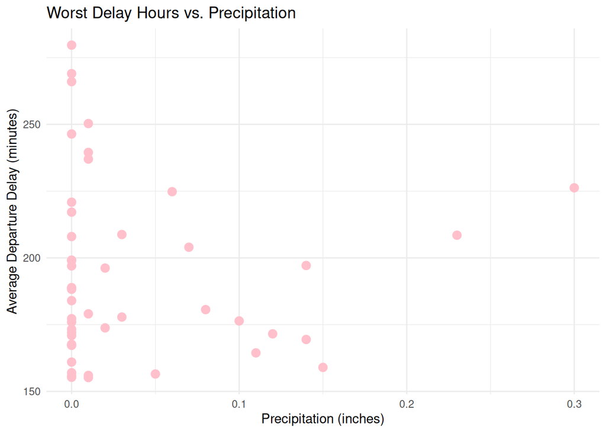

```r
library(nycflights13)
library(dplyr)
library(ggplot2)

flights <- flights %>% mutate(time_hour = as.POSIXct(time_hour))
weather <- weather %>% mutate(time_hour = as.POSIXct(time_hour))
worst_hours <- flights %>%
  group_by(origin, time_hour) %>%
  summarise(avg_dep_delay = mean(dep_delay, na.rm = TRUE), .groups = "drop") %>%
  arrange(desc(avg_dep_delay)) %>%
  slice_head(n = 48)
worst_weather <- worst_hours %>%
  left_join(weather, by = c("origin", "time_hour"))
ggplot(worst_weather, aes(x = precip, y = avg_dep_delay)) +
  geom_point(color = "pink", size = 3) +
  labs(title = "Worst Delay Hours vs. Precipitation",
       x = "Precipitation (inches)",
       y = "Average Departure Delay (minutes)") +
  theme_minimal()
```

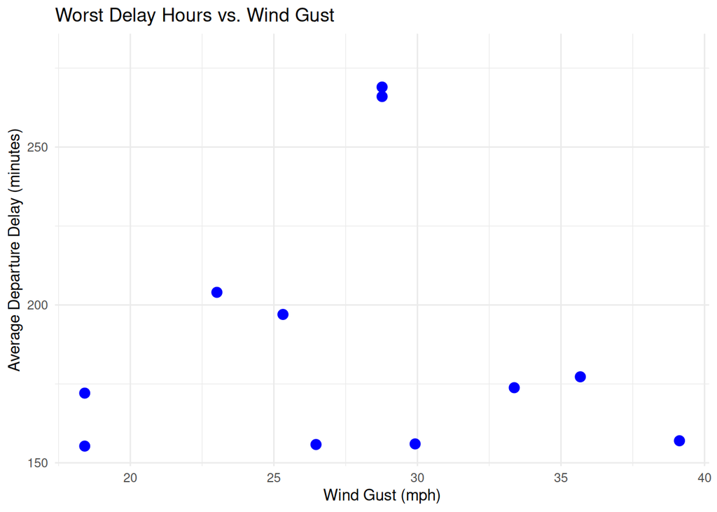

```r
ggplot(worst_weather, aes(x = wind_gust, y = avg_dep_delay)) +
  geom_point(color = "blue", size = 3) +
  labs(title = "Worst Delay Hours vs. Wind Gust",
       x = "Wind Gust (mph)",
       y = "Average Departure Delay (minutes)") +
  theme_minimal()
```

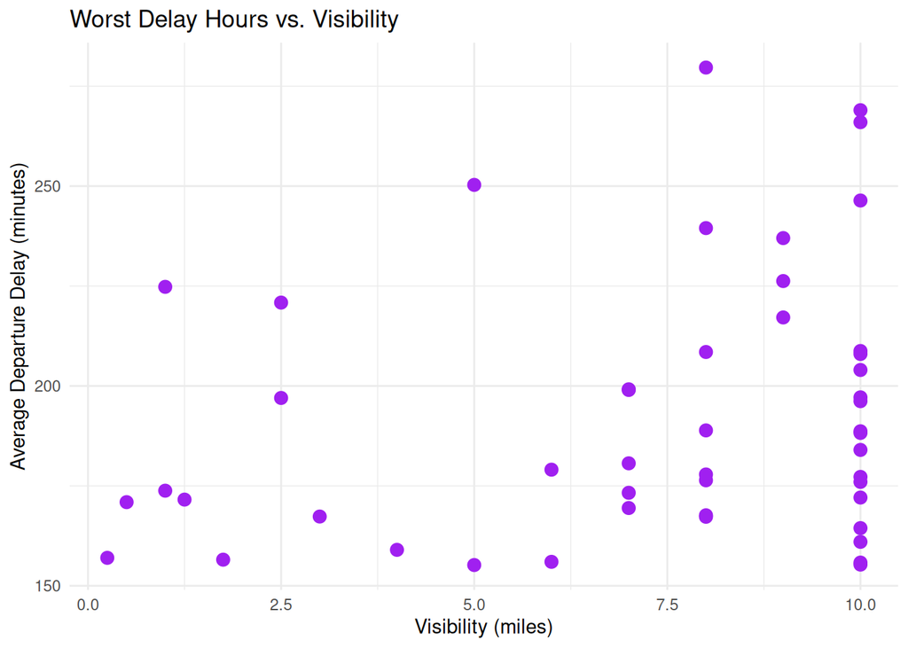

```r
ggplot(worst_weather, aes(x = visib, y = avg_dep_delay)) +
  geom_point(color = "purple", size = 3) +
  labs(title = "Worst Delay Hours vs. Visibility",
       x = "Visibility (miles)",
       y = "Average Departure Delay (minutes)") +
  theme_minimal()
```

### 2. Imagine you’ve found the top 10 most popular destinations using this code:

```r
top_dest <- flights2 |>
  count(dest, sort = TRUE) |>
  head(10)

top_dest
```

```
# A tibble: 10 × 2
   dest      n
   <chr> <int>
 1 ORD   17283
 2 ATL   17215
 3 LAX   16174
 4 BOS   15508
 5 MCO   14082
 6 CLT   14064
 7 SFO   13331
 8 FLL   12055
 9 MIA   11728
10 DCA    9705
```

### 3. Does every departing flight have corresponding weather data for that hour?

No, there are some missing data.

```r
flights %>%
  left_join(weather, by = c("origin", "time_hour")) %>%
  summarise(missing_weather = sum(is.na(temp)))
```

```
# A tibble: 1 × 1
  missing_weather
            <int>
1            1573
```

### 4. What do the tail numbers that don’t have a matching record in `planes` have in common? (Hint: one variable explains ~90% of the problems.)

```r
unmatched_tailnums <- flights %>%
  anti_join(planes, by = "tailnum")
unmatched_tailnums %>%
  summarise(
    total = n(),
    missing_tailnum = sum(is.na(tailnum)),
    percent_missing = mean(is.na(tailnum)) * 100
  )
```

```
# A tibble: 1 × 3
  total missing_tailnum percent_missing
  <int>           <int>           <dbl>
1 52606            2512            4.78
```

### 5. Add a column to `planes` that lists every `carrier` that has flown that plane. You might expect that there’s an implicit relationship between plane and airline, because each plane is flown by a single airline. Confirm or reject this hypothesis using the tools you’ve learned in previous chapters.

```r
planes_carriers <- planes %>%
  left_join(flights, by = "tailnum") %>%
  group_by(tailnum) %>%
  summarise(carriers = paste(unique(carrier), collapse = ", "),
            .groups = "drop")

planes_with_carriers <- planes %>%
  left_join(planes_carriers, by = "tailnum")
carrier_counts <- planes_with_carriers %>%
  mutate(num_carriers = lengths(strsplit(carriers, ", "))) %>%
  count(num_carriers)

carrier_counts
```

```
# A tibble: 2 × 2
  num_carriers     n
         <int> <int>
1            1  3305
2            2    17
```

### 6. Add the latitude and the longitude of the origin *and* destination airport to `flights`. Is it easier to rename the columns before or after the join?

```r
flights_geo <- flights %>%
  left_join(
    airports %>%
      select(faa, lat, lon) %>%
      rename(origin_lat = lat, origin_lon = lon),
    by = c("origin" = "faa")
  ) %>%
  left_join(
    airports %>%
      select(faa, lat, lon) %>%
      rename(dest_lat = lat, dest_lon = lon),
    by = c("dest" = "faa")
  )

head(flights_geo)
```

```
# A tibble: 6 × 23
   year month   day dep_time sched_dep_time dep_delay arr_time sched_arr_time
  <int> <int> <int>    <int>          <int>     <dbl>    <int>          <int>
1  2013     1     1      517            515         2      830            819
2  2013     1     1      533            529         4      850            830
3  2013     1     1      542            540         2      923            850
4  2013     1     1      544            545        -1     1004           1022
5  2013     1     1      554            600        -6      812            837
6  2013     1     1      554            558        -4      740            728
# ℹ 15 more variables: arr_delay <dbl>, carrier <chr>, flight <int>,
#   tailnum <chr>, origin <chr>, dest <chr>, air_time <dbl>, distance <dbl>,
#   hour <dbl>, minute <dbl>, time_hour <dttm>, origin_lat <dbl>,
#   origin_lon <dbl>, dest_lat <dbl>, dest_lon <dbl>
```

### 7. Compute the average delay by destination, then join on the `airports` data frame so you can show the spatial distribution of delays. Here’s an easy way to draw a map of the United States:

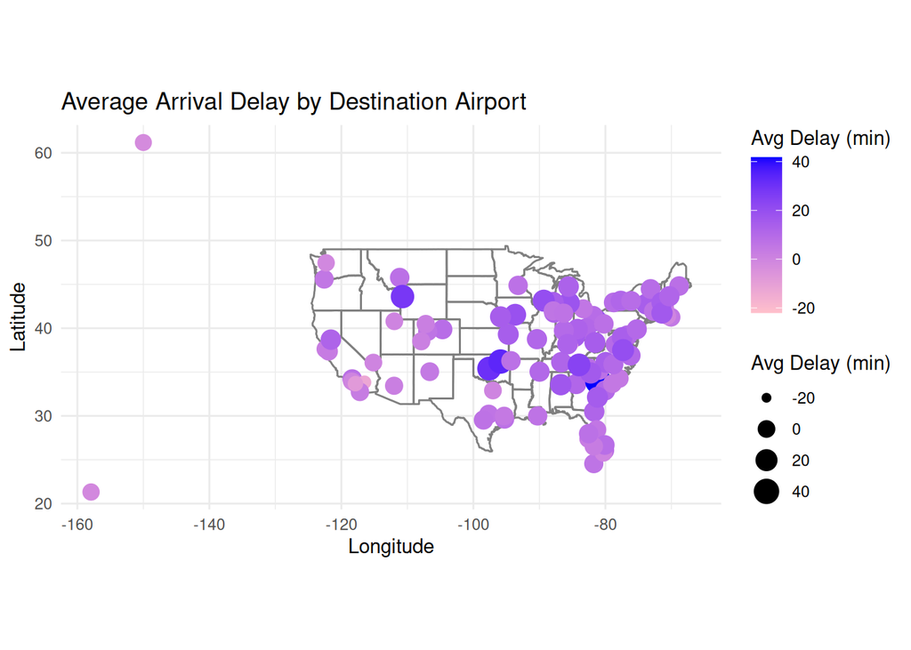

```r
avg_delay <- flights %>%
  group_by(dest) %>%
  summarise(mean_arr_delay = mean(arr_delay, na.rm = TRUE),
            .groups = "drop")

delay_map_data <- airports %>%
  inner_join(avg_delay, by = c("faa" = "dest"))

ggplot(delay_map_data, aes(x = lon, y = lat)) +
  borders("state") +
  geom_point(aes(color = mean_arr_delay, size = mean_arr_delay)) +
  coord_quickmap() +
  scale_color_gradient(low = "pink", high = "blue") +
  labs(title = "Average Arrival Delay by Destination Airport",
       x = "Longitude", y = "Latitude",
       color = "Avg Delay (min)", size = "Avg Delay (min)") +
  theme_minimal()
```

### 8. What happened on June 13 2013? Draw a map of the delays, and then use Google to cross-reference with the weather.

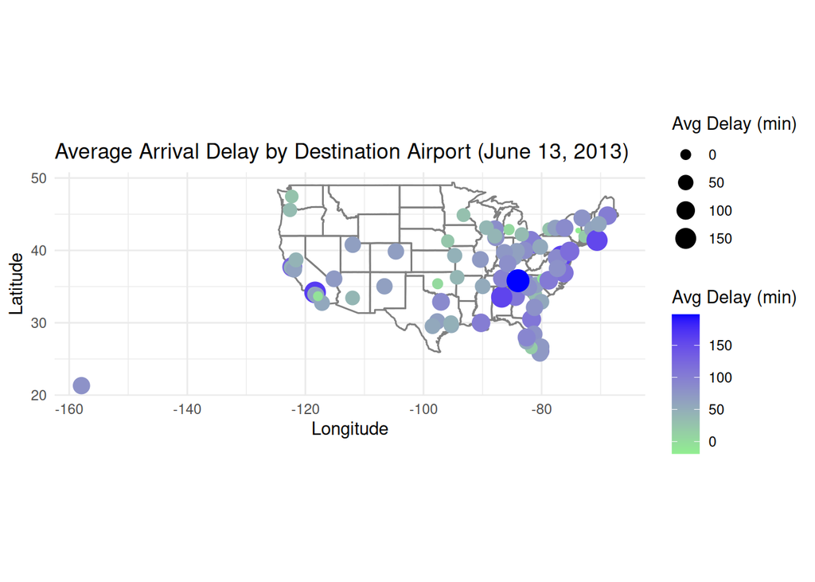

```r
flights_june13 <- flights %>%
  filter(year == 2013, month == 6, day == 13)
avg_delay_june13 <- flights_june13 %>%
  group_by(dest) %>%
  summarise(mean_arr_delay = mean(arr_delay, na.rm = TRUE),
            .groups = "drop")
delay_map_data <- airports %>%
  inner_join(avg_delay_june13, by = c("faa" = "dest"))
ggplot(delay_map_data, aes(x = lon, y = lat)) +
  borders("state") +
  geom_point(aes(color = mean_arr_delay, size = mean_arr_delay)) +
  coord_quickmap() +
  scale_color_gradient(low = "lightgreen", high = "blue") +
  labs(title = "Average Arrival Delay by Destination Airport (June 13, 2013)",
       x = "Longitude", y = "Latitude",
       color = "Avg Delay (min)", size = "Avg Delay (min)") +
  theme_minimal()
```

```r
flights_weather_june13 <- flights_june13 %>%
  left_join(weather, by = c("origin", "time_hour"))

flights_weather_june13 %>%
  filter(arr_delay > 120) %>%
  select(origin, dest, time_hour, arr_delay, precip, wind_gust, visib, temp) %>%
  arrange(desc(arr_delay)) %>%
  head(20)
```

```
# A tibble: 20 × 8
   origin dest  time_hour           arr_delay precip wind_gust visib  temp
   <chr>  <chr> <dttm>                  <dbl>  <dbl>     <dbl> <dbl> <dbl>
 1 LGA    MCO   2013-06-13 15:00:00       496   0         24.2  10    64.9
 2 LGA    ATL   2013-06-13 14:00:00       468   0         27.6  10    64.9
 3 JFK    RDU   2013-06-13 12:00:00       430   0         34.5  10    64.9
 4 JFK    IAD   2013-06-13 09:00:00       421   0         NA     7    64.9
 5 LGA    ATL   2013-06-13 19:00:00       420   0.08      NA     2.5  64.4
 6 JFK    TPA   2013-06-13 14:00:00       380   0         29.9  10    64.0
 7 LGA    MCO   2013-06-13 17:00:00       364   0         NA    10    66.0
 8 LGA    ATL   2013-06-13 17:00:00       341   0         NA    10    66.0
 9 LGA    ATL   2013-06-13 18:00:00       339   0         NA    10    64.9
10 LGA    BNA   2013-06-13 18:00:00       333   0         NA    10    64.9
11 LGA    TPA   2013-06-13 19:00:00       312   0.08      NA     2.5  64.4
12 EWR    MCO   2013-06-13 15:00:00       309   0         NA     8    64.9
13 EWR    MDW   2013-06-13 18:00:00       309   0         NA     7    66.0
14 LGA    FLL   2013-06-13 21:00:00       293   0.07      46.0   5    59
15 LGA    FLL   2013-06-13 11:00:00       287   0.23      20.7  10    64.0
16 JFK    RDU   2013-06-13 17:00:00       285   0         24.2   9    64.9
17 EWR    MSY   2013-06-13 18:00:00       277   0         NA     7    66.0
18 LGA    MIA   2013-06-13 19:00:00       274   0.08      NA     2.5  64.4
19 LGA    MCO   2013-06-13 13:00:00       266   0         27.6  10    64.0
20 LGA    CLE   2013-06-13 18:00:00       266   0         NA    10    64.9
```

## **19.5.5 Exercises**

### 1. Can you explain what’s happening with the keys in this equi join? Why are they different?

When there is no “keep=true” the join will merge the keys into one column but when there is “keep=true” then the keys will be in seperate columns.

```r
x |> full_join(y, join_by(key == key))
```

```
# A tibble: 4 × 3
    key val_x val_y
  <dbl> <chr> <chr>
1     1 x1    y1
2     2 x2    y2
3     3 x3    <NA>
4     4 <NA>  y3
```

```
#> # A tibble: 4 × 3
#>     key val_x val_y
#>   <dbl> <chr> <chr>
#> 1     1 x1    y1
#> 2     2 x2    y2
#> 3     3 x3    <NA>
#> 4     4 <NA>  y3
```

```r
x |> full_join(y, join_by(key == key), keep = TRUE)
```

```
# A tibble: 4 × 4
  key.x val_x key.y val_y
  <dbl> <chr> <dbl> <chr>
1     1 x1        1 y1
2     2 x2        2 y2
3     3 x3       NA <NA>
4    NA <NA>      4 y3
```

```
#> # A tibble: 4 × 4
#>   key.x val_x key.y val_y
#>   <dbl> <chr> <dbl> <chr>
#> 1     1 x1        1 y1
#> 2     2 x2        2 y2
#> 3     3 x3       NA <NA>
#> 4    NA <NA>      4 y3
```

### 2. When finding if any party period overlapped with another party period we used `q < q` in the [`join_by()`](https://dplyr.tidyverse.org/reference/join_by.html)? Why? What happens if you remove this inequality?

The “q < q” is used so that there is no duplicate pairs and also no self matches. If you remove the you’re code output could have duplicate pairs and self matches.